# ENTREGA_FINAL:¿Que variables afectan la mortalidad adulta a nivel mundial?

Curso: Estadística para el análisis político 2

# 1.Objetivo:

El presente informe tiene como objetivo un análisis de correlación entre la mortalidad adulta que se establece como la variable dependiente con las siguientes variables independientes de 143 países en el año 2015:

Variable Dependiente:

-Tasa de Mortalidad adulta en ambos sexos(entre los 15 y 60 años por cada 1000 habitantes)

variables Independientes:

-Porcentaje de la población con acceso a una cobertura de seguro de salud universal (PercentageUHC)

-Cantidad de profesionales de la salud por cada 10,000 habitantes(Medical_Doctors)

-Porcentaje de la población con acceso a servicios de agua potable(Water_Percentage)

-Porcentaje de consumo de litros de alcohol al año (total_litres_of_pure_alcohol)

-Porcentaje del índice de Masa muscular (Bmi)

-Porcentaje de consumo anual de azúcar en kilos (Sugar_and_sweetenersKg)

-Porcentaje de consumo anual de productos de animales en kilos (Animal_productskg)

Debemos aclarar que se entiende como mortalidad adulta lo siguiente:

La mortalidad adulta se refiere al número de fallecimientos en la población adulta en un determinado período de tiempo. La Organización Mundial de la Salud (OMS) define la mortalidad adulta como la tasa de defunciones ocurridas en individuos de 15 años de edad o más, por cada 1,000 personas de la misma edad en la población durante un año determinado.

# 2.Observamos la data:

La siguiente data es una base de datos, producto de un merge de diferentes bases da datos obtenidas de Kaggler,OMS, Banco Mundial y otros. Además, las bases de Kaggler poseen diferentes recapitulaciones de bases de datos de organismos oficiales alrededor del mundo como los mencionados anteriormente. Se realizó diversos procesos de Merge, llegando a alcanzar hasta 444,000 observaciones para cerca de 2200 variables.

Se optó por tomar en cuenta el año 2015 por la gran cantidad de información que se obtuvó, además de que la mayor base de datos obtenida tuvo procedencia de la OMS, y este fue una de las bases más completas revisadas.

Se realizó una ardua limpieza que concluyó en una data de 143 observaciones(países) con 9 variables utilizadas para esta investigación. El resto de variables que no se observan son referentes al año de la data (2015), al país y al código oficial del país.

```
## 'data.frame':    143 obs. of  12 variables:
##  $ Country                     : chr  "Afghanistan" "Albania" "Algeria" "Angola" ...
##  $ country_code                : chr  "AFG" "ALB" "DZA" "AGO" ...
##  $ year                        : num  2015 2015 2015 2015 2015 ...
##  $ PercentageUHC               : num  0.49 0.31 0.36 0.31 0.34 0.44 0.54 0.41 0.33 0.33 ...
##  $ Medical_doctors             : num  1.74 12.77 17.19 0.62 40.01 ...
##  $ total_litres_of_pure_alcohol: num  0 4.9 0.7 5.9 8.3 3.8 10.4 9.7 1.3 6.3 ...
##  $ WaterPercentage             : num  57.3 89.9 88.7 27.4 99.6 ...
##  $ Age                         : num  55.4 70.7 77.5 65.5 78.6 ...
##  $ bmi                         : num  23.3 26.6 25.5 23.2 27.6 26.3 27.1 25.5 26.9 27.9 ...
##  $ Sugar_and_SweetenersKg      : num  1.35 1.54 1.83 1.85 3.05 ...
##  $ Animal_ProductsKG           : num  9.43 18.77 9.63 4.93 19.35 ...
##  $ adult_mortality             : num  233.2 92.2 96.5 239.8 112.7 ...
##  - attr(*, "na.action")= 'omit' Named int [1:14] 11 18 23 33 45 46 85 113 119 127 ...
##   ..- attr(*, "names")= chr [1:14] "11" "18" "23" "33" ...
```

Aquí observaremos todas las variables mencionadas:

```
##  [1] "Country"                      "country_code"
##  [3] "year"                         "PercentageUHC"
##  [5] "Medical_doctors"              "total_litres_of_pure_alcohol"
##  [7] "WaterPercentage"              "Age"
##  [9] "bmi"                          "Sugar_and_SweetenersKg"
## [11] "Animal_ProductsKG"            "adult_mortality"
```

# Regresión Lineal Múltiple

Se optó por un modelo de Regresión lineal (Regresión Gaussiana) debido al tipo de variables que se utilizó, todas nuestras variables fueron de tipo numérico.

Inicialmente se tomó en cuenta factores en común que compartan nuestras variables independientes y concluimos que podían agruparse de la siguiente manera:

Factores asociados a políticas públicas: Condiciones que están determinadas por instituciones del Estado. (PercentageUHC, Medical_Doctors, Water_Percentage)

Factores asociados a patrones alimenticios: Condiciones que están determinadas por el propio individuo. (total_litres_of_pure_alcohol, Sugar_and_sweetenersKg, Bmi, Animal_productskg) Posteriormente, evaluaremos cada grupo con un determinado modelo de regresión lineal para identificar a las variables que tienen mayor influencia sobre la variable dependiente.

En la comparación de modelos de regresión en base a los grupos de variables mencionados anteriormente encontramos, como esperabamos, que los factores asociados a políticas públicas tenían mayor efecto en la variable dependiente. No obstante, por una cuestión de requisitos, tuvimos que modificar el modelo y se realizó el siguiente:

Hipótesis Modelo1:

Hipótesis Modelo2:

H0: La mortalidad adulta esta afectada significativamente por la cantidad de alcohol consumida en litros, el índice de masa corporal, la cantidad de azúcarpor kilogramos consumida anualmente y la cantidad de proteína animal consumidad por kilogramos anualmente.

```r
modelo1<-lm(adult_mortality ~ PercentageUHC + Medical_doctors + WaterPercentage+Sugar_and_SweetenersKg + Animal_ProductsKG, data)

modelo2<-lm(adult_mortality ~ total_litres_of_pure_alcohol + bmi + Sugar_and_SweetenersKg + Animal_ProductsKG, data)


models = list(modelo1,modelo2)
modelsummary(models, output = "kableExtra")
```

|  | (1) | (2) |
| --- | --- | --- |
| (Intercept) | 432.121 | 570.247 |
|  | (28.893) | (73.974) |
| PercentageUHC | -59.422 |  |
|  | (58.601) |  |
| Medical_doctors | -0.644 |  |
|  | (0.514) |  |
| WaterPercentage | -2.595 |  |
|  | (0.303) |  |
| Sugar_and_SweetenersKg | -0.401 | -2.202 |
|  | (3.113) | (3.887) |
| Animal_ProductsKG | -1.746 | -7.687 |
|  | (1.199) | (1.196) |
| total_litres_of_pure_alcohol |  | 1.899 |
|  |  | (1.751) |
| bmi |  | -12.397 |
|  |  | (3.194) |
| Num.Obs. | 143 | 143 |
| R2 | 0.650 | 0.460 |
| R2 Adj. | 0.637 | 0.445 |
| AIC | 1550.1 | 1609.8 |
| BIC | 1570.8 | 1627.6 |
| Log.Lik. | -768.033 | -798.894 |
| F | 50.786 | 29.436 |
| RMSE | 52.04 | 64.57 |

# Tabla ANOVA: Comparación de Modelos

-Optamos por considera al Modelo 1, como el mejor para la explicación de nuestra VD.

```
## Analysis of Variance Table
##
## Model 1: adult_mortality ~ PercentageUHC + Medical_doctors + WaterPercentage +
##     Sugar_and_SweetenersKg + Animal_ProductsKG
## Model 2: adult_mortality ~ total_litres_of_pure_alcohol + bmi + Sugar_and_SweetenersKg +
##     Animal_ProductsKG
##   Res.Df    RSS Df Sum of Sq      F    Pr(>F)
## 1    137 387197
## 2    138 596187 -1   -208989 73.946 1.639e-14 ***
## ---
## Signif. codes:  0 '***' 0.001 '**' 0.01 '*' 0.05 '.' 0.1 ' ' 1
```

# Modelo Estandarizado

Observamos los coeficientes estandarizados para un mejor análisis del efecto de nuestras variables.

Regresion: modelo con coeficientes estandarizados

|  | (1) |
| --- | --- |
| (Intercept) | 0.000 |
|  | (0.050) |
| scale(PercentageUHC) | -0.055 |
|  | (0.054) |
| scale(Medical_doctors) | -0.103 |
|  | (0.082) |
| scale(WaterPercentage) | -0.630*** |
|  | (0.074) |
| scale(Sugar_and_SweetenersKg) | -0.007 |
|  | (0.056) |
| scale(Animal_ProductsKG) | -0.119 |
|  | (0.082) |
| Num.Obs. | 143 |
| R2 | 0.650 |
| R2 Adj. | 0.637 |
| AIC | 268.9 |
| BIC | 289.6 |
| Log.Lik. | -127.435 |
| F | 50.786 |
| RMSE | 0.59 |

+ p < 0.1, * p < 0.05, ** p < 0.01, *** p < 0.001

# Diagosticos de la Regresión:

Revisamos los supuestos para comprobar la validez de nuestro modelo:

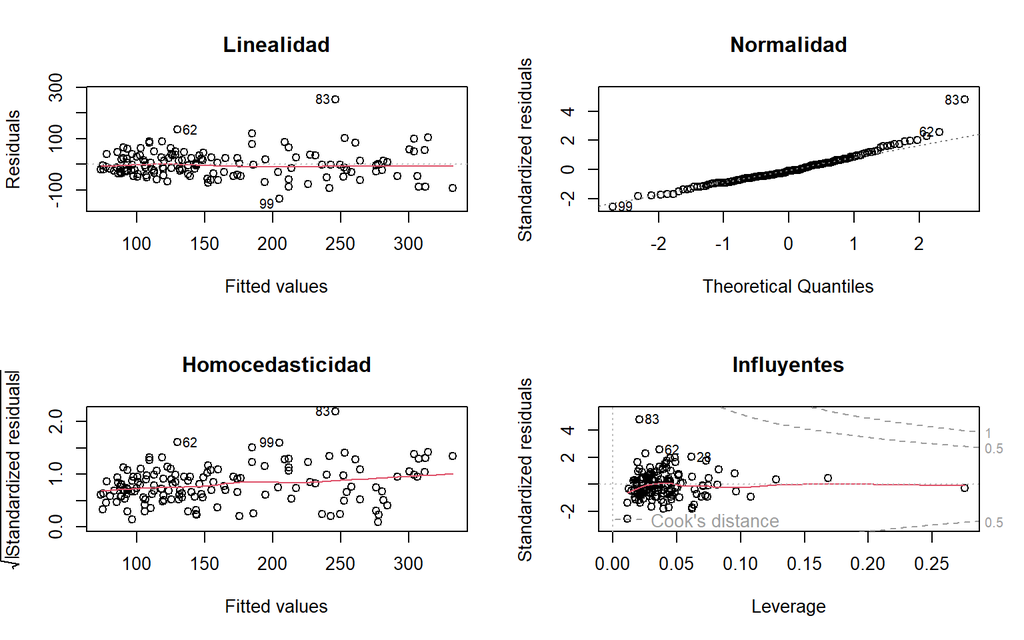

# ANALISIS DE CONGLOMERADOS

Las variables de nuestra base de datos, y por ende de nuestro modelo, tienen diferentes tendencias estadísticas. Dado que son variables muy diferentes, esto puede afectar nuestro analisis. Procederemos a estandarizar las variables para mejorar nuestro proceso de clusterización.

Utilizaremos el método: standardize.

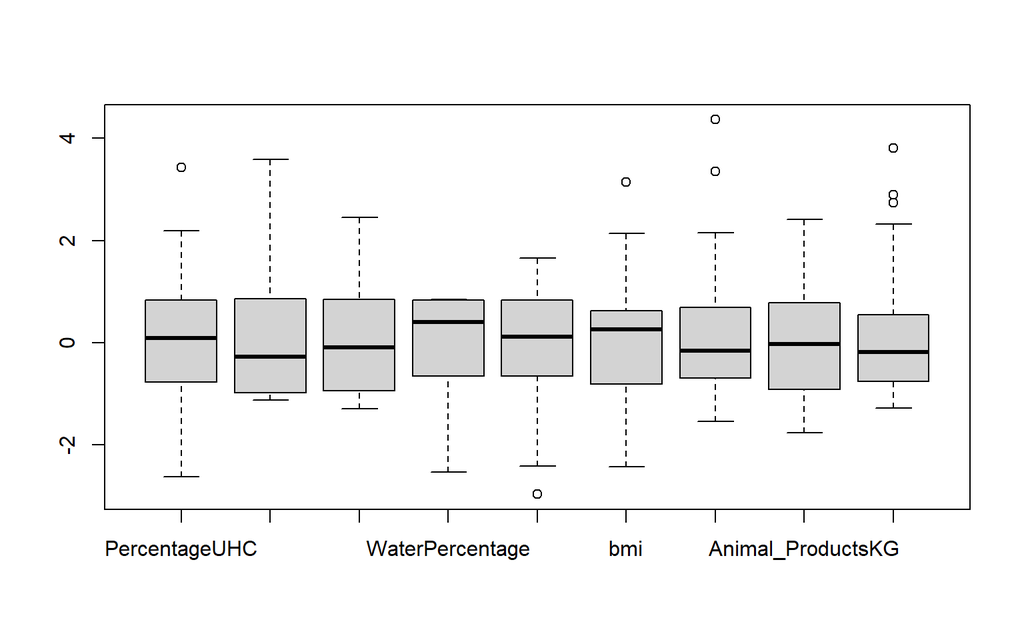

# Cantidad de Clusters: PAM

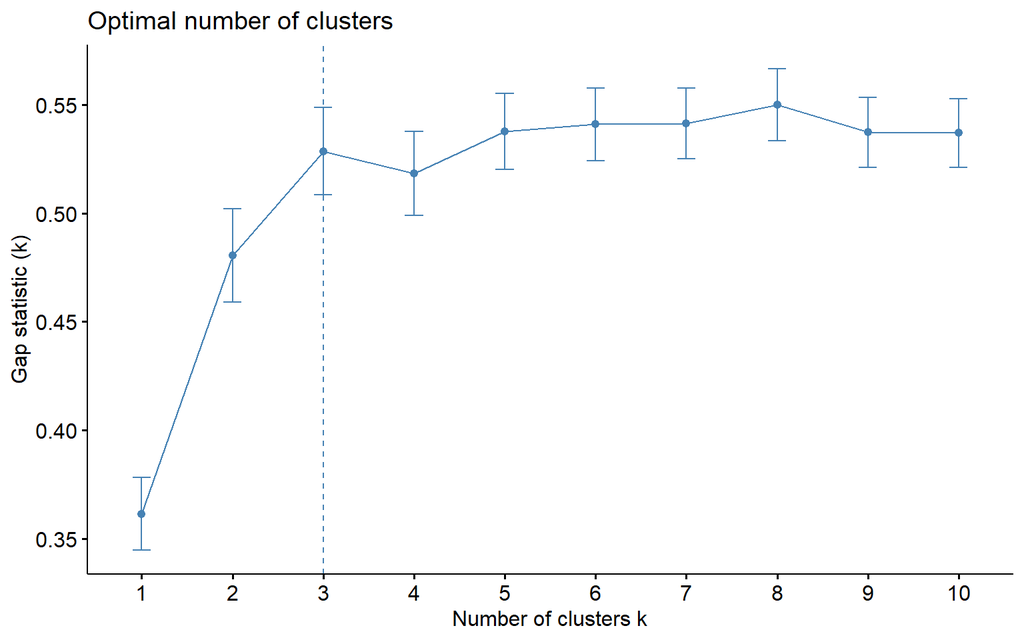

La tecnica nos propone 3 clusters.

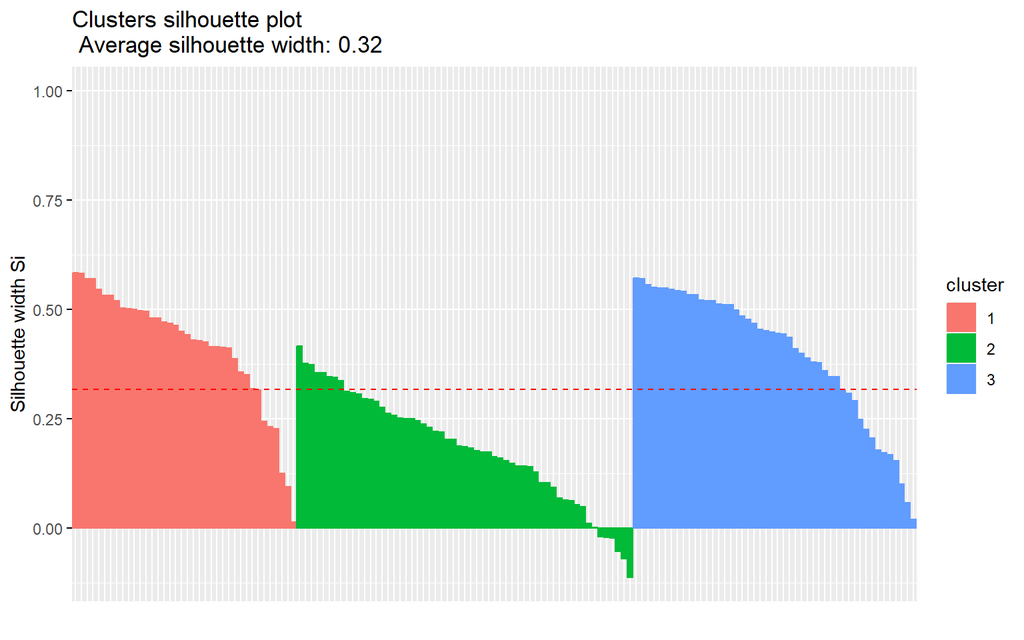

# DATOS MAL CLUSTERIZADOS VÍA PAM:

```
## [1] "Cambodia"    "Cuba"        "Ecuador"     "Mexico"      "Panama"
## [6] "Timor-Leste"
```

# Gráfica de Clusters:

Dando coordenadas a nuestros resultados:

Trás la aplicación de una técnica multidimensional, observamos posiciones a partir de las distancias de los países.

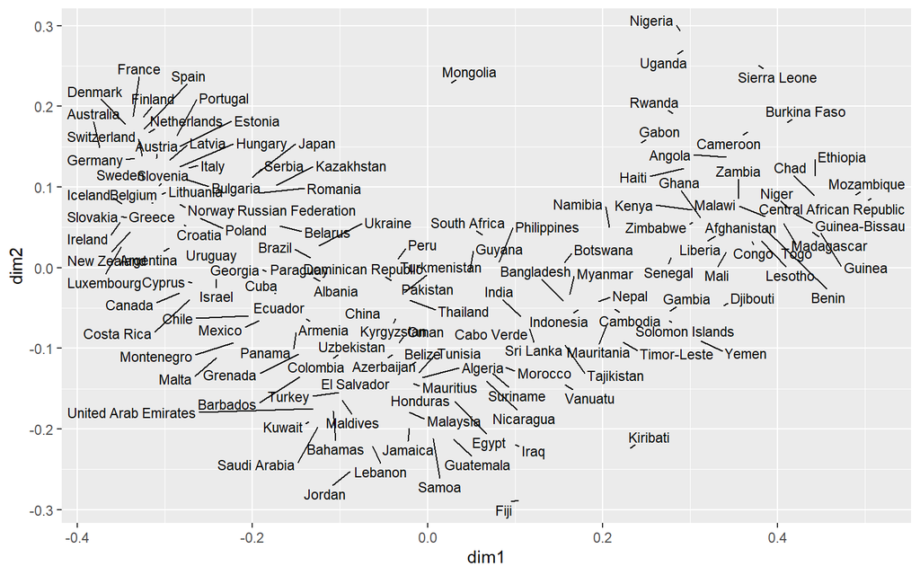

# GRÁFICA DE PAM:

Se observan los países mal clusterizados.

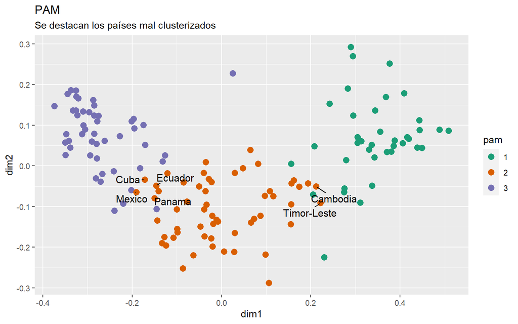

# Bibliografía:

Alex Teboul. (n.d.). Diabetes Health Indicators Dataset. Kaggle. https://www.kaggle.com/datasets/alexteboul/diabetes-health-indicators-dataset

Ben Coleman. (n.d.). Global Health Data Analysis. Kaggle. https://www.kaggle.com/code/benbcoleman/global-health-data-analysis/input

Daniel Evans. (n.d.). World Bank WDI-212: Health Systems. Kaggle. https://www.kaggle.com/datasets/danevans/world-bank-wdi-212-health-systems

Darshan Prabhu. (n.d.). Countries Economy (GDP and Everything). Kaggle. https://www.kaggle.com/datasets/darshanprabhu09/countries-economy-gdp-and-everything

Dmitry Azarov. (n.d.). Visualization and Mortality Prediction. Kaggle. https://www.kaggle.com/code/dmitryazarov/visualization-and-mortality-prediction

Gabriel Luiz. (n.d.). Mortality Information System. Kaggle. https://www.kaggle.com/datasets/gabrielluizone/mortality-information-system

John Harshith. (n.d.). World Happiness Report 2021 & Worldwide Mortality. Kaggle. https://www.kaggle.com/datasets/johnharshith/world-happiness-report-2021-worldwide-mortality

Kumar Rajarshi. (n.d.). Life Expectancy (WHO). Kaggle. https://www.kaggle.com/datasets/kumarajarshi/life-expectancy-who

Maria Ren. (n.d.). COVID-19 Healthy Diet Dataset. Kaggle. https://www.kaggle.com/datasets/mariaren/covid19-healthy-diet-dataset?select=Food_Supply_Quantity_kg_Data.csv

Marília Antunes. (n.d.). Rank MD. Kaggle. https://www.kaggle.com/datasets/mpwolke/cusersmarildownloadsrankmdcsv

Matt Mattson. (n.d.). WHO National Life Expectancy. Kaggle. https://www.kaggle.com/datasets/mmattson/who-national-life-expectancy/code

MySar Ahmad Bhat. (n.d.). Alcohol Consumption. Kaggle. https://www.kaggle.com/datasets/mysarahmadbhat/alcohol-consumption

ORGANIZACIÓN MUNDIAL DE LA SALUD (OMS) 2023 GHO | By category | Adult mortality - Data by country. Global Health Observatory Data Repository. Adult Mortality Data by Country. https://apps.who.int/gho/data/view.main.1360?lang=en

PsyCon. (n.d.). Population Estimates and Projections. Kaggle.m https://www.kaggle.com/datasets/psycon/population-estimates-and-projections

University of Michigan. (n.d.). Sleep, Health, and Lifestyle Dataset. Kaggle. https://www.kaggle.com/datasets/uom190346a/sleep-health-and-lifestyle-dataset